# Matplotlib: A scientific visualization toolbox

## Introduction

- matplotlib is probably the single most used Python package for 2D-graphics.
- It provides both a very quick way to visualize data from Python and publication-quality figures in many formats.
- We are going to explore matplotlib in interactive mode covering most common cases.

### IPython and the pylab mode

[IPython](http://ipython.org/) is an enhanced interactive Python shell that has lots of interesting features including named inputs and outputs, access to shell commands, improved debugging and many more. When we start it with the command line argument -pylab (--pylab since IPython version 0.12), it allows interactive matplotlib sessions that have Matlab/Mathematica-like functionality.

### pyplot

- pyplot provides a convenient interface to the matplotlib object-oriented plotting library.
- It is modeled closely after Matlab(TM). Therefore, the majority of plotting commands in pyplot have Matlab(TM) analogs with similar arguments.
- Important commands are explained with interactive examples.

[figure not shown]

- So before we start, a word on imports. What do you think about these imports? Why are they bad?
- They hide where functionality came from. Is this squareroot from numpy or math or your own function?
- Is this plot from seaborn or pandas or matplotlib or something else?
- Never use import *. It makes your code less readable. And we don’t want that, right?
- Always use explicit imports and standard naming conventions. I haven’t decided if I’ll subtract points for that, but if I see that I will know that I failed.

## Two-dimensional plots

- **Axes** should not be confused with **axis**.
- An *Axes* is the area of the plot containing the lines/points/markers of data.
- *Axis* are the coordinate axis of the plot. See the figure for reference.

A Matplotlib plot contains

- One or more `Axes` which each contain an individual plot
- A `Figure` which is the final image containing one or more Axes

[figure not shown]

Image credit: [Matplotlib 1.5.1 FAQ](https://matplotlib.org/1.5.1/faq/usage_faq.html#parts-of-a-figure)

- *Axes* are what are traditionally thought of as the *area* of the plot.
- These can contain the actual coordinate axis and tick marks, the lines or line markers for the data being plotting, legend, title, axis labels, etc.
- The *Figure* can contain more than one `Axes`.
- These `Axes` could appear side-by-side or in a grid, or they can appear essentially on top of one another where they share an $x$ or $y$ axis.
- The `Figure` can also contain a color bar in a contour or surface plot and a title.

The following figure taken from the [Matplotlib FAQ](https://matplotlib.org/faq/usage_faq.html) is useful reference identifying the different parts of a two-dimensional plot.

[figure not shown]

Image credit: [Matplotlib FAQ](https://matplotlib.org/faq/usage_faq.html)

## Simple plot

In this section, we want to draw the cosine and sine functions on the same plot. Starting from the default settings, we'll enrich the figure step by step to make it nicer.

First step is to get the data for the sine and cosine functions:

```python
import numpy as np

X = np.linspace(-np.pi, np.pi, 256, endpoint=True)
C,S = np.cos(X), np.sin(X)
```

X is now a numpy array with 256 values ranging -π to +π (included). C is the cosine (256 values) and S is the sine (256 values).

### Using defaults

- Matplotlib comes with a set of default settings that allow customizing all kinds of properties.
- You can control the defaults of almost every property in matplotlib: figure size and dpi (dots per inch), line width, color and style, axes, axis and grid properties, text and font properties and so on.
- While matplotlib defaults are rather good in most cases, you may want to modify some properties for specific cases.

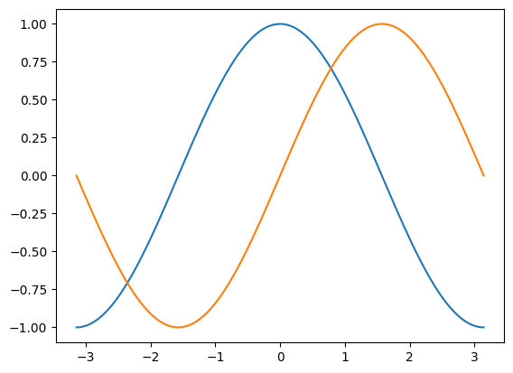

```python
import numpy as np
import matplotlib.pyplot as plt

X = np.linspace(-np.pi, np.pi, 256, endpoint=True)
C,S = np.cos(X), np.sin(X)

# plot C and S
plt.plot(X, C)
plt.plot(X, S)

plt.show()
```

### Instantiating defaults

- In the script below, we've instantiated (and commented) all the figure settings that influence the appearance of the plot.
- The settings have been explicitly set to their default values, but now you can interactively play with the values to explore their affect (see Line properties, Line styles and Markers below).

[figure not shown]

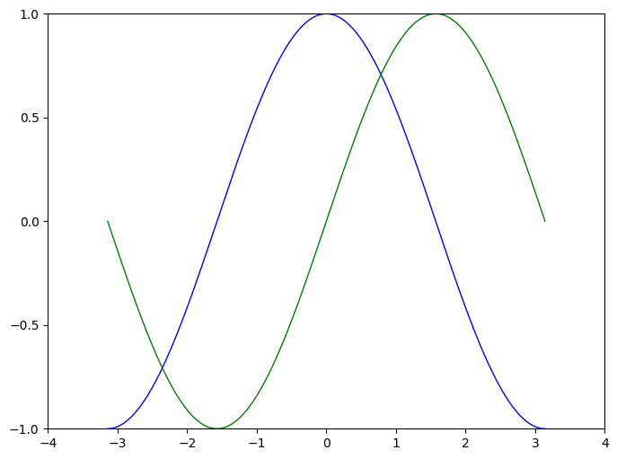

```python
# Imports
import numpy as np
import matplotlib.pyplot as plt

# Create a new figure of size 8x6 points, using 100 dots per inch
#####
plt.figure(figsize=(8, 6), dpi=100)

# Create a new subplot from a grid of 1x1
#####
plt.subplot(1, 1, 1)

X = np.linspace(-np.pi, np.pi, 256,endpoint=True)
C,S = np.cos(X), np.sin(X)

# Plot cosine using blue color with a continuous line of width 1 (pixels)
#####
plt.plot(X, C, color="blue", linewidth=1.0, linestyle='-')

# Plot sine using green color with a continuous line of width 1 (pixels)
#####
plt.plot(X, S, color="green", linewidth=1.0, linestyle='-')

# Set x limits to (-4.0, 4.0)
#####
plt.xlim(-4.0, 4.0)

# Set x ticks
#####
plt.xticks(np.linspace(-4,4,9, endpoint=True))

# Set y limits
#####
plt.ylim(-1.0, 1.0)

# Set y ticks
#####
plt.yticks(np.linspace(-1, 1, 5))

# Save figure using 72 dots per inch
# savefig("../figures/exercice_2.png",dpi=72)

# Show result on screen
plt.show()
```

### Changing colors and line widths

First step, we want to have the cosine in blue and the sine in red and a slightly thicker line for both of them. We'll also slightly alter the figure size to make it more horizontal.

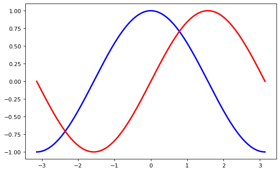

```python
import numpy as np
import matplotlib.pyplot as plt

plt.figure(figsize=(8,5), dpi=80)
plt.subplot(111)

X = np.linspace(-np.pi, np.pi, 256,endpoint=True)
C,S = np.cos(X), np.sin(X)

# Changing colors and line widths
#####
plt.plot(X, C, color="blue", linewidth=2.5, linestyle='-')
plt.plot(X, S, color="red", linewidth=2.5, linestyle='-')
#####

plt.show()
```

### Setting limits

Current limits of the figure are a bit too tight and we want to make some space in order to clearly see all data points.

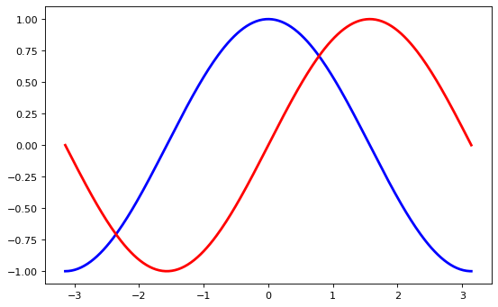

```python
import numpy as np
import matplotlib.pyplot as plt

plt.figure(figsize=(8,5), dpi=80)
plt.subplot(111)

X = np.linspace(-np.pi, np.pi, 256,endpoint=True)
C,S = np.cos(X), np.sin(X)

plt.plot(X, C, color="blue", linewidth=2.5, linestyle="-")
plt.plot(X, S, color="red", linewidth=2.5, linestyle="-")

# Setting limits to the range (min*1.1 ~ max*1.1)
#####
plt.xlim(X.min()*1.1, X.max()*1.1)
plt.ylim(C.min()*1.1, C.max()*1.1)
#####

plt.show()
```

### Setting ticks

Current ticks are not ideal because they do not show the interesting values (+/-π,+/-π/2) for sine and cosine. We'll change them such that they show only these values.

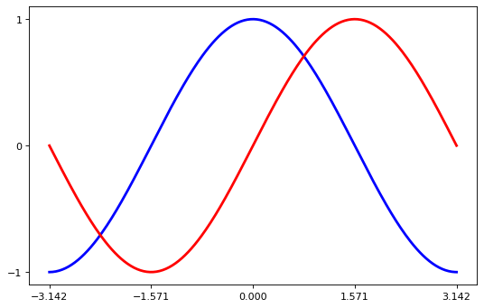

```python
import numpy as np
import matplotlib.pyplot as plt

plt.figure(figsize=(8,5), dpi=80)
plt.subplot(111)

X = np.linspace(-np.pi, np.pi, 256,endpoint=True)
C,S = np.cos(X), np.sin(X)

plt.plot(X, C, color="blue", linewidth=2.5, linestyle="-")
plt.plot(X, S, color="red", linewidth=2.5, linestyle="-")

plt.xlim(X.min()*1.1, X.max()*1.1)
# setting x-ticks
#####
plt.xticks([-np.pi, -np.pi/2, 0, np.pi/2, np.pi])

plt.ylim(C.min()*1.1,C.max()*1.1)
# setting y-ticks
#####
plt.yticks([-1, 0, 1])

plt.show()
```

### Setting tick labels

- Ticks are now properly placed but their label is not very explicit.
- We could guess that 3.142 is π but it would be better to make it explicit.
- When we set tick values, we can also provide a corresponding label in the second argument list.
- Note that we'll use latex to allow for nice rendering of the label.

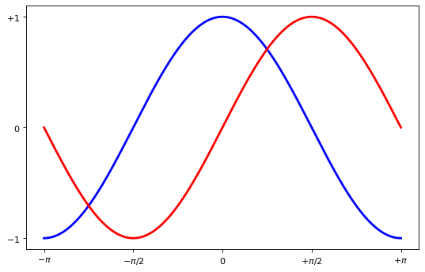

```python
import numpy as np
import matplotlib.pyplot as plt

plt.figure(figsize=(8,5), dpi=80)
plt.subplot(111)

X = np.linspace(-np.pi, np.pi, 256,endpoint=True)
C,S = np.cos(X), np.sin(X)

plt.plot(X, C, color="blue", linewidth=2.5, linestyle="-")
plt.plot(X, S, color="red", linewidth=2.5, linestyle="-")

plt.xlim(X.min()*1.1, X.max()*1.1)

# Setting tick labels
plt.xticks([-np.pi, -np.pi/2, 0, np.pi/2, np.pi],
       [r'$-\pi$', r'$-\pi/2$', r'$0$', r'$+\pi/2$', r'$+\pi$'])

plt.ylim(C.min()*1.1,C.max()*1.1)

# Setting tick labels
plt.yticks([-1, 0, +1],
       [r'$-1$', r'$0$', r'$+1$'])

plt.show()
```

### Moving spines

- Spines are the lines connecting the axis tick marks and noting the boundaries of the data area.
- They can be placed at arbitrary positions and until now, they were on the border of the axis.
- We'll change that since we want to have them in the middle.
- Since there are four of them (top/bottom/left/right), we'll discard the top and right by setting their color to none and we'll move the bottom and left ones to coordinate 0 in data space coordinates.

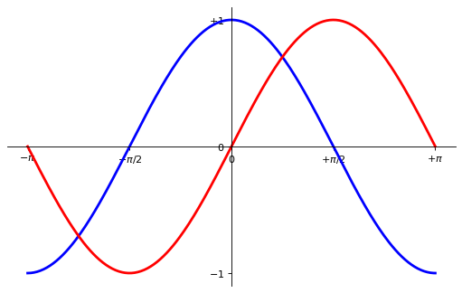

```python
import numpy as np
import matplotlib.pyplot as plt

plt.figure(figsize=(8,5), dpi=80)
ax = plt.subplot(111)

# moving spines
#####
ax.spines['right'].set_color('none')
ax.spines['top'].set_color('none')
ax.xaxis.set_ticks_position('bottom')
ax.spines['bottom'].set_position(('data', 0))
ax.yaxis.set_ticks_position('left')
ax.spines['left'].set_position(('data', 0))
#####

X = np.linspace(-np.pi, np.pi, 256,endpoint=True)
C,S = np.cos(X), np.sin(X)

plt.plot(X, C, color="blue", linewidth=2.5, linestyle="-")
plt.plot(X, S, color="red", linewidth=2.5, linestyle="-")


plt.xlim(X.min()*1.1, X.max()*1.1)
plt.xticks([-np.pi, -np.pi/2, 0, np.pi/2, np.pi],
       [r'$-\pi$', r'$-\pi/2$', r'$0$', r'$+\pi/2$', r'$+\pi$'])

plt.ylim(C.min()*1.1,C.max()*1.1)
plt.yticks([-1, 0, +1],
       [r'$-1$', r'$0$', r'$+1$'])

plt.show()
```

### Adding a legend

- Let's add a legend in the upper left corner.
- This only requires adding the keyword argument label (that will be used in the legend box) to the plot commands.

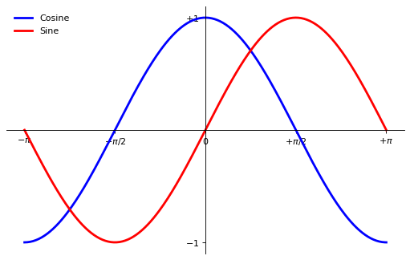

```python
import numpy as np
import matplotlib.pyplot as plt

plt.figure(figsize=(8,5), dpi=80)
ax = plt.subplot(111)

# moving spines
ax.spines['right'].set_color('none')
ax.spines['top'].set_color('none')
ax.xaxis.set_ticks_position('bottom')
ax.spines['bottom'].set_position(('data',0))
ax.yaxis.set_ticks_position('left')
ax.spines['left'].set_position(('data',0))

X = np.linspace(-np.pi, np.pi, 256,endpoint=True)
C,S = np.cos(X), np.sin(X)

# plot graph with labels
#####
plt.plot(X, C, color="blue", linewidth=2.5, linestyle="-", label="Cosine")
plt.plot(X, S, color="red", linewidth=2.5, linestyle="-", label="Sine")
#####

plt.xlim(X.min()*1.1, X.max()*1.1)
plt.xticks([-np.pi, -np.pi/2, 0, np.pi/2, np.pi],
           [r'$-\pi$', r'$-\pi/2$', r'$0$', r'$+\pi/2$', r'$+\pi$'])

plt.ylim(C.min()*1.1,C.max()*1.1)
plt.yticks([-1, +1],
           [r'$-1$', r'$+1$'])

# Adding a legend
#####
plt.legend(loc='upper left', frameon=False)

plt.show()
```

### Annotate some points

- Let's annotate some interesting points using the annotate command.
- We chose the 2π/3 value and we want to annotate both the sine and the cosine.
- We'll first draw a marker on the curve as well as a straight dotted line.
- Then, we'll use the annotate command to display some text with an arrow.

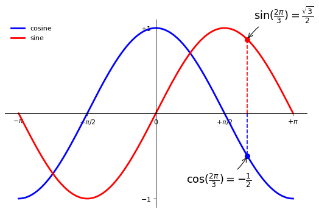

```python
import numpy as np
import matplotlib.pyplot as plt

plt.figure(figsize=(8,5), dpi=80)
ax = plt.subplot(111)

# moving spines
ax.spines['right'].set_color('none')
ax.spines['top'].set_color('none')
ax.xaxis.set_ticks_position('bottom')
ax.spines['bottom'].set_position(('data',0))
ax.yaxis.set_ticks_position('left')
ax.spines['left'].set_position(('data',0))

X = np.linspace(-np.pi, np.pi, 256,endpoint=True)
C,S = np.cos(X), np.sin(X)

plt.plot(X, C, color="blue", linewidth=2.5, linestyle="-", label="cosine")
plt.plot(X, S, color="red", linewidth=2.5, linestyle="-",  label="sine")

plt.xlim(X.min()*1.1, X.max()*1.1)
plt.xticks([-np.pi, -np.pi/2, 0, np.pi/2, np.pi],
           [r'$-\pi$', r'$-\pi/2$', r'$0$', r'$+\pi/2$', r'$+\pi$'])

plt.ylim(C.min()*1.1,C.max()*1.1)
plt.yticks([-1, +1],
           [r'$-1$', r'$+1$'])

# Dotted vertical line for cosine (e.g., 2pi/3)
t = 2*np.pi/3
plt.plot([t,t],[0,np.cos(t)], #점선을 넣어준다
         color ='blue',  linewidth=1.5, linestyle="--")
# Point for cosine (e.g., 2pi/3)
plt.scatter([t,],[np.cos(t),], 50, color ='blue')

# Annotate some points (e.g., 2pi/3)
plt.annotate(r'$\cos(\frac{2\pi}{3})=-\frac{1}{2}$',
             xy=(t, np.cos(t)),  xycoords='data',
             xytext=(-90, -40), textcoords='offset points', fontsize=16,
             arrowprops=dict(arrowstyle="->", connectionstyle="arc3,rad=.2"))

# Dotted vertical line for sine (e.g., 2pi/3)
plt.plot([t,t],[0,np.sin(t)],
         color ='red',  linewidth=1.5, linestyle="--")
# Point for sine (e.g., 2pi/3)
plt.scatter([t,],[np.sin(t),], 50, color ='red')

# Annotate some points
plt.annotate(r'$\sin(\frac{2\pi}{3})=\frac{\sqrt{3}}{2}$',
             xy=(t, np.sin(t)),  xycoords='data',
             xytext=(+10, +30), textcoords='offset points', fontsize=16,
             arrowprops=dict(arrowstyle="->", connectionstyle="arc3,rad=.2"))

plt.legend(loc='upper left', frameon=False)

plt.show()
```

### Devil is in the details

- The tick labels are now hardly visible because of the blue and red lines.
- We can make them bigger and we can also adjust their properties such that they'll be rendered on a semi-transparent white background.
- This will allow us to see both the data and the labels.

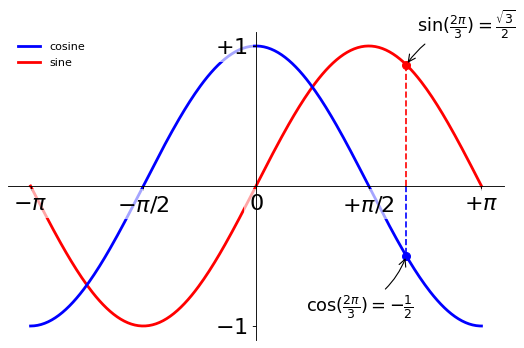

```python
import numpy as np
import matplotlib.pyplot as plt

plt.figure(figsize=(8,5), dpi=80)
ax = plt.subplot(111)
ax.spines['right'].set_color('none')
ax.spines['top'].set_color('none')
ax.xaxis.set_ticks_position('bottom')
ax.spines['bottom'].set_position(('data',0))
ax.yaxis.set_ticks_position('left')
ax.spines['left'].set_position(('data',0))

X = np.linspace(-np.pi, np.pi, 256,endpoint=True)
C,S = np.cos(X), np.sin(X)

plt.plot(X, C, color="blue", linewidth=2.5, linestyle="-", label="cosine",
         zorder=-1)
plt.plot(X, S, color="red", linewidth=2.5, linestyle="-",  label="sine",
         zorder=-2)


plt.xlim(X.min()*1.1, X.max()*1.1)
plt.xticks([-np.pi, -np.pi/2, 0, np.pi/2, np.pi],
           [r'$-\pi$', r'$-\pi/2$', r'$0$', r'$+\pi/2$', r'$+\pi$'])

plt.ylim(C.min()*1.1,C.max()*1.1)
plt.yticks([-1, +1],
           [r'$-1$', r'$+1$'])

plt.legend(loc='upper left', frameon=False)

t = 2*np.pi/3
plt.plot([t,t],[0,np.cos(t)],
         color ='blue',  linewidth=1.5, linestyle="--")
plt.scatter([t,],[np.cos(t),], 50, color ='blue')
plt.annotate(r'$\sin(\frac{2\pi}{3})=\frac{\sqrt{3}}{2}$',
             xy=(t, np.sin(t)),  xycoords='data',
             xytext=(+10, +30), textcoords='offset points', fontsize=16,
             arrowprops=dict(arrowstyle="->", connectionstyle="arc3,rad=.2"))

plt.plot([t,t],[0,np.sin(t)],
         color ='red',  linewidth=1.5, linestyle="--")
plt.scatter([t,],[np.sin(t),], 50, color ='red')
plt.annotate(r'$\cos(\frac{2\pi}{3})=-\frac{1}{2}$',
             xy=(t, np.cos(t)),  xycoords='data',
             xytext=(-90, -50), textcoords='offset points', fontsize=16,
             arrowprops=dict(arrowstyle="->", connectionstyle="arc3,rad=.2"))

### Devil is in the details
for label in ax.get_xticklabels() + ax.get_yticklabels():
    label.set_fontsize(20)
    label.set_bbox(dict(facecolor='white', edgecolor='None', alpha=0.65)) # 글자가 더 잘보이게 흰색 배경 넣기

plt.show()
```

## Figures, Subplots, and Axes and Ticks

- So far we have used implicit figure and axes creation.
- This is handy for fast plots.
- We can have more control over the display using figure, subplot, and axes explicitly.
- A figure in matplotlib means the whole window in the user interface.
- Within this figure, there can be subplots.
- While subplot positions the plots in a regular grid, axes allows free placement within the figure.
- Both can be useful depending on your intention.
- We've already worked with figures and subplots without explicitly calling them.
- When we call plot, matplotlib calls gca() to get the current axes and gca in turn calls gcf() to get the current figure.
- If there is none it calls figure() to make one, strictly speaking, to make a subplot(111).
- Let's look at the details.

### Figures

- A figure is the windows in the GUI that has "Figure #" as title.
- Figures are numbered starting from 1 as opposed to the normal Python way starting from 0.
- This is clearly MATLAB-style.
- There are several parameters that determine what the figure looks like:

[figure not shown]

- The defaults can be specified in the resource file and will be used most of the time.
- Only the number of the figure is frequently changed.
- When you work with the GUI, you can close a figure by clicking on the x in the upper right corner.
- But you can close a figure programmatically by calling close.
- Depending on the argument it closes (1) the current figure (no argument), (2) a specific figure (figure number or figure instance as argument), or (3) all figures (all as argument).
- As with other objects, you can set figure properties with the set_something methods.

### Subplots

- With subplot you can arrange plots in a regular grid.
- You need to specify the number of rows and columns and the number of the plot.
- Note that the **gridspec** command is a more powerful alternative.

[figure not shown]

### subplot-horizontal

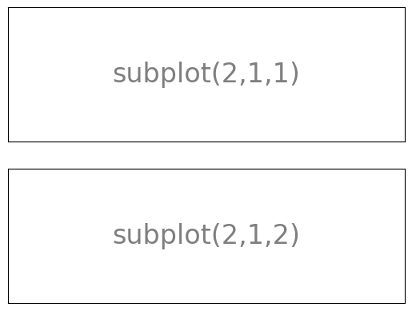

```python
from pylab import *

# plot figures like below

#####
subplot(2, 1, 1)
xticks([]), yticks([])
text(0.5, 0.5, 'subplot(2,1,1)', ha='center', va='center', size=24, alpha=0.5)
#####

#####
subplot(2, 1, 2)
xticks([]), yticks([])
text(0.5, 0.5, 'subplot(2,1,2)', ha='center', va='center', size=24, alpha=0.5)
#####

show()
```

### subplot-vertical

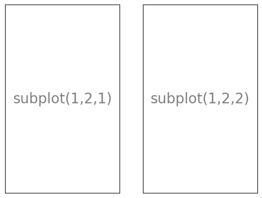

```python
from pylab import *
# plot figures like below

#####
subplot(1,2,1)
xticks([]), yticks([])
text(0.5, 0.5, 'subplot(1,2,1)', ha='center', va='center', size=20, alpha=0.5)
#####

#####
subplot(1,2,2)
xticks([]), yticks([])
text(0.5, 0.5, 'subplot(1,2,2)', ha='center', va='center', size=20, alpha=0.5)
#####

show()
```

### subplot-grid

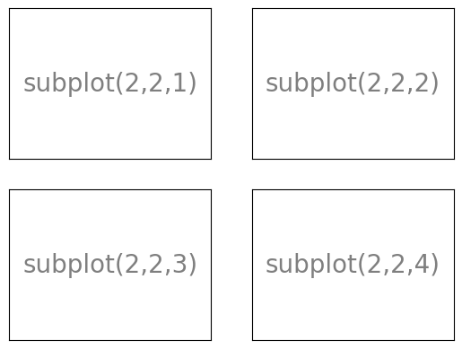

```python
from pylab import *

# plot figures like below

subplot(2,2,1)
xticks([]), yticks([])
text(0.5, 0.5, 'subplot(2,2,1)', ha='center', va='center', size=20, alpha=0.5)
#####

subplot(2,2,2)
xticks([]), yticks([])
text(0.5, 0.5, 'subplot(2,2,2)', ha='center', va='center', size=20, alpha=0.5)
#####

subplot(2,2,3)
xticks([]), yticks([])
text(0.5, 0.5, 'subplot(2,2,3)', ha='center', va='center', size=20, alpha=0.5)
#####

subplot(2,2,4)
xticks([]), yticks([])
text(0.5, 0.5, 'subplot(2,2,4)', ha='center', va='center', size=20, alpha=0.5)
#####

# savefig('../figures/subplot-grid.png', dpi=64)
show()
```

### gridspec

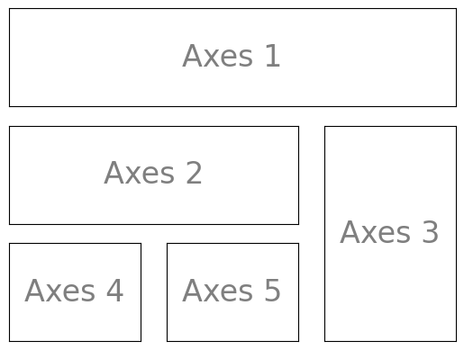

```python
from pylab import *
import matplotlib.gridspec as gridspec

# plot figures like below

G = gridspec.GridSpec(3, 3)

#####
axex_1=subplot(G[0, :])
xticks([]), yticks([])
text(0.5,0.5, 'Axes 1',ha='center',va='center',size=24,alpha=.5)

#####
axex_2=subplot(G[1, :-1])
xticks([]), yticks([])
text(0.5,0.5, 'Axes 2',ha='center',va='center',size=24,alpha=.5)

#####
axex_3=subplot(G[1:, -1])
xticks([]), yticks([])
text(0.5,0.5, 'Axes 3',ha='center',va='center',size=24,alpha=.5)

#####
axex_4=subplot(G[-1, 0])
xticks([]), yticks([])
text(0.5,0.5, 'Axes 4',ha='center',va='center',size=24,alpha=.5)

#####
axex_5=subplot(G[-1, -2])
xticks([]), yticks([])
text(0.5,0.5, 'Axes 5',ha='center',va='center',size=24,alpha=.5)

show()
```

### Axes

- Axes are very similar to subplots but allow placement of plots at any location in the figure.
- So if we want to put a smaller plot inside a bigger one, we do so with axes.

[figure not shown]

```python
### axes-1
```

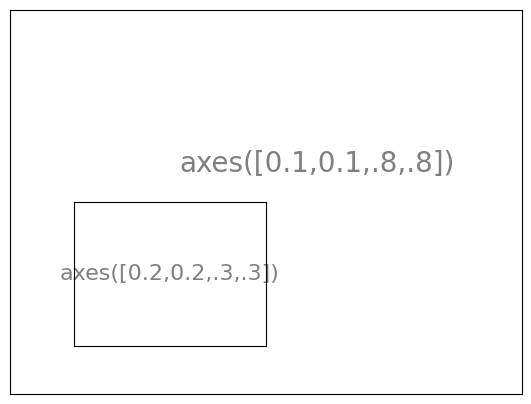

```python
import matplotlib.pyplot as plt

# plot figures like below
#####
plt.axes([0.1, 0.1, .8, .8])
plt.xticks([]), plt.yticks([])
plt.text(0.6,0.6, 'axes([0.1,0.1,.8,.8])',ha='center',va='center',size=20,alpha=.5)

#####
plt.axes([0.2,0.2,.3,.3])
plt.xticks([]), plt.yticks([])
plt.text(0.5,0.5, 'axes([0.2,0.2,.3,.3])',ha='center',va='center',size=16,alpha=.5)

plt.show()
```

```python
### axes-2
```

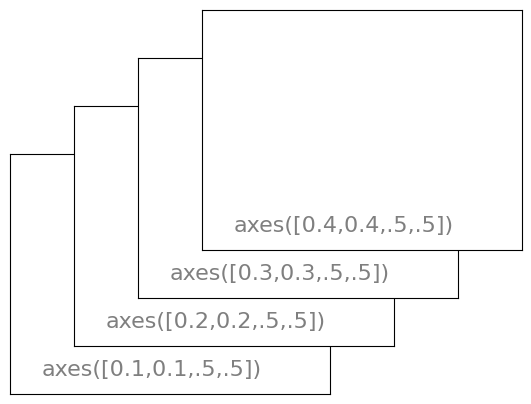

```python
import matplotlib.pyplot as plt

# plot figures like below
#####
plt.axes([0.1,0.1,.5,.5])
plt.xticks([]), plt.yticks([])
plt.text(0.1,0.1, 'axes([0.1,0.1,.5,.5])',ha='left',va='center',size=16,alpha=.5)

#####
plt.axes([0.2,0.2,.5,.5])
plt.xticks([]), plt.yticks([])
plt.text(0.1,0.1, 'axes([0.2,0.2,.5,.5])',ha='left',va='center',size=16,alpha=.5)

#####
plt.axes([0.3,0.3,.5,.5])
plt.xticks([]), plt.yticks([])
plt.text(0.1,0.1, 'axes([0.3,0.3,.5,.5])',ha='left',va='center',size=16,alpha=.5)

#####
plt.axes([0.4,0.4,.5,.5])
plt.xticks([]), plt.yticks([])
plt.text(0.1,0.1, 'axes([0.4,0.4,.5,.5])',ha='left',va='center',size=16,alpha=.5)

plt.show()
```

### Ticks

- Well formatted ticks are an important part of publishing-ready figures.
- Matplotlib provides a totally configurable system for ticks.
- There are **tick locators** to specify where ticks should appear and **tick formatters** to give ticks the appearance you want.
- Major and minor ticks can be located and formatted independently from each other.
- Per default minor ticks are not shown, i.e. there is only an empty list for them because it is as NullLocator (see below).

### Tick locators

There are several locators for different kinds of requirements:

[figure not shown]

- All of these locators derive from the base class matplotlib.ticker.Locator.
- You can make your own locator deriving from it.
- Handling dates as ticks can be especially tricky.
- Therefore, matplotlib provides special locators in matplotlib.dates.